# Adaptive Governance Results

Stress Test and Robustness Analysis

Author

Mikus

Published

July 5, 2026

# Adaptive Governance Extension – Statistical Results

## Purpose

This report documents the exploratory adaptive governance extension presented in Chapter 8.2 of the thesis. It summarizes the simulation results, reproduces the reported tables, and documents the experimental setup used to evaluate the adaptive governance mechanism under increasingly severe demand shocks.

## Experimental Setup

The adaptive governance extension compares the baseline Interaction scenario with an event-triggered Adaptive Governance mechanism under repeated demand shocks.

Simulation settings:

- Fleet size: N = 80 vehicles
- Backlog carry-over: 50%
- Simulation horizon: 500 ticks
- Monte Carlo replications: 50 random seeds
- Shock intensities: 4×, 6× and 8× demand multipliers
- Compared scenarios:
  - Interaction
  - Adaptive Governance

## Adaptive Governance Mechanism

Adaptive governance is activated only during severe system stress.

Activation requires:

- spatial demand-supply imbalance > 0.14
- overload present during at least three of the previous five ticks

When active:

- price adjustments are limited to δ = 2.0
- rebalancing remains unconstrained (θ = 0, Rmax = 999)

The objective is to stabilize prices while preserving matching performance.

## Data

The tables below summarize the aggregated simulation results used in Chapter 8.2 of the thesis.

The reported values correspond to:

- 50 Monte Carlo replications
- 500 simulation ticks
- fleet size N = 80
- 50% backlog carry-over

```r
# Stress test results — aggregated means across 50 seeds
stress_results <- tibble::tribble(
  ~regime,              ~peak_multiplier, ~revenue_per_vehicle, ~service_rate, ~overload_frequency, ~avg_spatial_imbalance, ~max_spatial_imbalance, ~price_volatility, ~price_oscillation_index, ~activation_frequency,
  "interaction",        4.0, 1232.1113925309419, 0.7304528787513452, 0.33524, 0.07374775,          0.13904166666666667, 2.950908334286979,  0.3313669222343921,  0.0,
  "adaptive_governance",4.0, 1231.588508567167,  0.7304965191284348, 0.33536, 0.07375766666666667, 0.13904166666666667, 2.9484561849635917, 0.33112595837897046, 4e-05,
  "interaction",        6.0, 2541.4177223958127, 0.6143501485357683, 0.48888, 0.08610125,          0.14883333333333332, 6.705741525237844,  0.23701935012778388, 0.0,
  "adaptive_governance",6.0, 2519.998636686285,  0.6149662760142646, 0.48712, 0.0860295,           0.14825,             6.618060990299904,  0.23894706097115737, 0.00236,
  "interaction",        8.0, 3943.939540627044,  0.5195265642543233, 0.56436, 0.09973725000000001, 0.18341666666666667, 10.9366145161902,   0.18443762930509922, 0.0,
  "adaptive_governance",8.0, 3219.0020835417263, 0.506742938347789,  0.55224, 0.10068366666666666, 0.19012500000000002, 9.134486805944254,  0.22327929901423876, 0.06984
)

# OFAT robustness results — aggregated means across 50 seeds under 8.0x shock
robustness_results <- tibble::tribble(
  ~parameter_group, ~delta, ~theta, ~Rmax, ~service_rate,       ~overload_frequency, ~revenue_per_vehicle, ~price_volatility,   ~spatial_imbalance,         ~activation_frequency,
  "delta",          1.0,    0,      999,   0.5041310440661363,  0.55492,             3121.656749422404,    8.938468102625347,   0.1010165,                  0.0752,
  "delta",          2.0,    0,      999,   0.506742938347789,   0.55224,             3219.0020835417263,   9.134486805944254,   0.10068366666666666,        0.06984,
  "delta",          3.0,    0,      999,   0.5073573181242841,  0.5580,              3260.8139025556393,   9.210886137111459,   0.10060408333333333,        0.06848,
  "theta",          2.0,    0,      999,   0.506742938347789,   0.55224,             3219.0020835417263,   9.134486805944254,   0.10068366666666666,        0.06984,
  "theta",          2.0,    1,      999,   0.5035011400909818,  0.55704,             3146.4615438226097,   8.988194624758217,   0.10118483333333333,        0.07708,
  "theta",          2.0,    2,      999,   0.5049064610514518,  0.5592,              3161.1028037763167,   9.027075680817719,   0.10111675,                 0.07876,
  "Rmax",           2.0,    0,      999,   0.506742938347789,   0.55224,             3219.0020835417263,   9.134486805944254,   0.10068366666666666,        0.06984,
  "Rmax",           2.0,    0,      15,    0.505853914234924,   0.5556,              3213.318340017244,    9.146336767398225,   0.10084416666666668,        0.06972,
  "Rmax",           2.0,    0,      10,    0.5056462812198029,  0.55192,             3196.252282747309,    9.09301600806078,    0.10086308333333333,        0.07224
)

# Clean labels for stress results
stress_clean <- stress_results %>%
  mutate(
    regime_label = case_when(
      regime == "interaction" ~ "Interaction",
      regime == "adaptive_governance" ~ "Adaptive Governance",
      TRUE ~ regime
    )
  )
```

### Main Summary Table

The table summarizes the results for the Interaction and Adaptive Governance scenarios across all three shock levels.

Table 8.2a: Adaptive Governance Stress Test Results (N=80)

| Shock Level | Scenario | Service Rate | Overload Frequency | Revenue / Vehicle | Price Volatility | Spatial Imbalance | Max Spatial Imbalance | Adaptive Activation % |
| --- | --- | --- | --- | --- | --- | --- | --- | --- |
| 4 | Interaction | 73.05% | 33.52% | $1232.11 | 2.951 | 0.074 | 0.139 | 0.00% |
| 4 | Adaptive Governance | 73.05% | 33.54% | $1231.59 | 2.948 | 0.074 | 0.139 | 0.00% |
| 6 | Interaction | 61.44% | 48.89% | $2541.42 | 6.706 | 0.086 | 0.149 | 0.00% |
| 6 | Adaptive Governance | 61.50% | 48.71% | $2520.00 | 6.618 | 0.086 | 0.148 | 0.24% |
| 8 | Interaction | 51.95% | 56.44% | $3943.94 | 10.937 | 0.100 | 0.183 | 0.00% |
| 8 | Adaptive Governance | 50.67% | 55.22% | $3219.00 | 9.134 | 0.101 | 0.190 | 6.98% |

### Difference Table

The following table summarizes the performance differences (Adaptive Governance − Interaction) across all shock levels.

Table 8.2b: Metric Deltas (Adaptive Governance vs. Interaction)

| Shock Level | Change in Service Rate | Change in Overload Freq. | Change in Revenue / Vehicle | Change in Price Volatility | Price Volatility Reduction % | Change in Spatial Imbalance | Activation Frequency |
| --- | --- | --- | --- | --- | --- | --- | --- |
| 4 | +0.00% | +0.01% | $-0.52 | -0.002 | 0.08% | +0.000 | 0.00% |
| 6 | +0.06% | -0.18% | $-21.42 | -0.088 | 1.31% | -0.000 | 0.24% |
| 8 | -1.28% | -1.21% | $-724.94 | -1.802 | 16.48% | +0.001 | 6.98% |

### Parameter Robustness

To evaluate whether the results depend on the selected parameter values, a one-factor-at-a-time (OFAT) robustness analysis was performed under the most demanding scenario (8.0× repeated demand shock). In each experiment, only one parameter was changed while all others remained at their baseline values.

The baseline adaptive governance configuration uses $\delta = 2.0$, $\theta = 0$, and $R_{max} = 999$. This configuration is included in each parameter group for reference. The robustness analysis examines alternative values of the price damping parameter ($\delta$), the rebalancing threshold ($\theta$), and the maximum rebalancing rate ($R_{max}$), allowing the sensitivity of the reported performance metrics to be assessed.

Table 8.2c: One-Factor-At-A-Time Parameter Robustness under 8.0x Repeated Shock

| Parameter Group | Configuration | Service Rate | Overload Frequency | Revenue / Vehicle | Price Volatility | Spatial Imbalance | Activation Frequency |
| --- | --- | --- | --- | --- | --- | --- | --- |
| delta | delta = 1 (theta=0, Rmax=999) | 50.41% | 55.49% | $3121.66 | 8.938 | 0.101 | 7.52% |
| delta | delta = 2 (theta=0, Rmax=999) | 50.67% | 55.22% | $3219.00 | 9.134 | 0.101 | 6.98% |
| delta | delta = 3 (theta=0, Rmax=999) | 50.74% | 55.80% | $3260.81 | 9.211 | 0.101 | 6.85% |
| theta | theta = 0 (delta=2.0, Rmax=999) | 50.67% | 55.22% | $3219.00 | 9.134 | 0.101 | 6.98% |
| theta | theta = 1 (delta=2.0, Rmax=999) | 50.35% | 55.70% | $3146.46 | 8.988 | 0.101 | 7.71% |
| theta | theta = 2 (delta=2.0, Rmax=999) | 50.49% | 55.92% | $3161.10 | 9.027 | 0.101 | 7.88% |
| Rmax | Rmax = 999 (delta=2.0, theta=0) | 50.67% | 55.22% | $3219.00 | 9.134 | 0.101 | 6.98% |
| Rmax | Rmax = 15 (delta=2.0, theta=0) | 50.59% | 55.56% | $3213.32 | 9.146 | 0.101 | 6.97% |
| Rmax | Rmax = 10 (delta=2.0, theta=0) | 50.56% | 55.19% | $3196.25 | 9.093 | 0.101 | 7.22% |

### Visualizations

Plot price volatility and adaptive activation frequency across the shock multipliers.

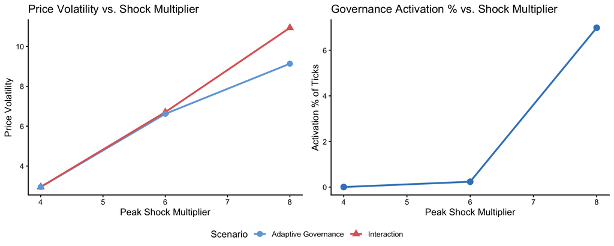

## Interpretation and Conclusions

The adaptive governance mechanism remains inactive under the 4.0× demand shock, indicating that the calibrated system can handle moderate stress without additional intervention.

At the 6.0× shock level, the trigger activates only occasionally and slightly reduces price volatility.

The robustness analysis shows that these findings remain consistent across different parameter settings.

Overall, adaptive governance acts as an emergency mechanism that activates only under severe system stress. As this extension was evaluated outside the main hypothesis-testing framework, the results should be considered exploratory.